# 1. Introduction

Paolo Di Lorenzo

2025-08-22

## Plotting

Plots of US maps in R usually lack Alaska, Hawaii, and Puerto Rico. The reason is plotting takes the literal longitude and latitude coordinates and maps it to a cartesian x-y coordinate graph. Alaska, Hawaii, and Puerto Rico are very far from the mainland US when using this so it can be unwieldy to include them. The `usmap` package solves this issue by providing data frames which have Alaska, Hawaii, and Puerto Rico moved to a convenient spot just to the bottom left of the contiguous United States.

#### Blank US state map

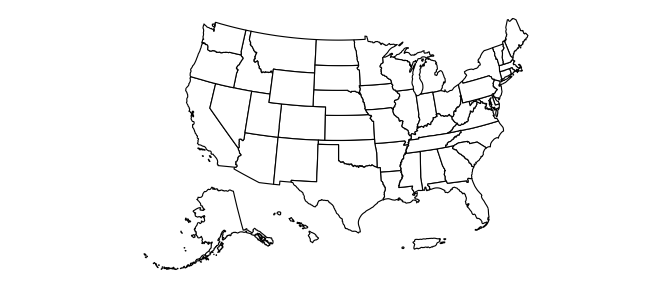

```r
usmap::plot_usmap()
```

#### Blank US county map

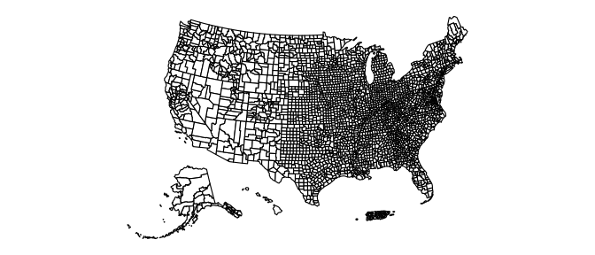

```r
usmap::plot_usmap(regions = "counties")
```

## Raw map data

The raw US map data for counties or states can be obtained for further manipulation (and joining with data). The default `regions` is `"states"`.

```r
states_df <- usmap::us_map()
counties_df <- usmap::us_map(regions = "counties")
```

## FIPS codes

FIPS codes are defined in the Federal Information Processing Standards by the US government. One usage is uniquely identifying US states and counties. Downloaded data sets from the [US Census](https://www.census.gov/data.html) will often include FIPS codes as identifiers so it can be helpful to know what a FIPS code represents. The functions in `usmap` are built around the FIPS code identification system and so convenience methods for accessing them and performing reverse-lookups have been included.

#### State/County FIPS lookup

```r
# Get FIPS code for a state
usmap::fips(state = "MA")
```

```
#> [1] "25"
```

```r
usmap::fips(state = "Massachusetts")
```

```
#> [1] "25"
```

```r
# Get FIPS code for a county
usmap::fips(state = "NJ", county = "Bergen")
```

```
#> [1] "34003"
```

```r
usmap::fips(state = "CA", county = "Orange County")
```

```
#> [1] "06059"
```

```r
# The parameters are NOT case sensitive!
usmap::fips(state = "ca", county = "oRanGe cOUNty")
```

```
#> [1] "06059"
```

#### FIPS reverse lookup

If the FIPS code is known and want to see what state/county it corresponds to, use the reverse lookup function `fips_info`.

```r
usmap::fips_info(c("30", "33", "34"))
```

```
#>   abbr fips          full
#> 1   MT   30       Montana
#> 2   NH   33 New Hampshire
#> 3   NJ   34    New Jersey
```

```r
usmap::fips_info(c("01001", "01003", "01005", "01007"))
```

```
#>      full abbr         county  fips
#> 1 Alabama   AL Autauga County 01001
#> 2 Alabama   AL Baldwin County 01003
#> 3 Alabama   AL Barbour County 01005
#> 4 Alabama   AL    Bibb County 01007
```

#### Further reading

More information about FIPS can be read [here](https://en.wikipedia.org/wiki/Federal_Information_Processing_Standards).

> “A map is the greatest of all epic poems. Its lines and colors show the realization of great dreams.” - *Gilbert H. Grosvenor, Editor of National Geographic (1903 - 1954)*